# Bloch oscillation in a dynamically modulated ring resonator

Monday, October 23, 2023 | 10 minutes

- Julia
- Tutorial
- Reproduced paper

```julia
1using LatticeModels, Plots; LM = LatticeModels
2using QuantumOptics
3using Plots.Measures
4
5default(fmt=:png,
6    fontfamily="computer modern", titlefont="computer modern", tickfont="computer modern";
7    linewidth=2, legend_position=:best
8 )
```

We want to reproduce the Bloch oscillation in a ring resonator. A ring resonator with a dynamic refractive index modulation can exhibit Bloch oscillation of light along the frequency axis, as a result of an effective force for photons induced by the modulation, as is shown in [Yuan et al (2016)](https://doi.org/10.1364/OPTICA.3.001014).

Furthermore, we want to show that one can deduce directional transport on the frequency axis by switching the detuning periodically.

We will implement the model ad deduced in [Yuan et al (2016)](https://doi.org/10.1364/OPTICA.3.001014): $$ \tilde{H}=g \sum_m\left(c_m^{\dagger} c_{m+1}+c_{m+1}^{\dagger} c_m\right)+\sum_m m \Delta(t) c_m^{\dagger} c_m, $$ where $m$ is the resonant mode of the waveguide in the resonator, $g$ is the strength of the modulation, and $\Delta$ is the detuning of the resonant frequency of the waveguide from the modulation frequency.

[figure not shown]

```julia
1size=100
2lattice = SquareLattice(size, 1)
3x_basis = PositionBasis(0, size, size)
4
5sample = Sample(lattice, boundaries=BoundaryConditions(1 => true, 2 => true))
6system = System(sample, μ=0.0, statistics=LM.OneParticle)
```

```
LatticeModels.FilledZones{Sample{Nothing, SquareLattice{2}, Nothing, BoundaryConditions{Tuple{TwistedBoundary, TwistedBoundary}}}}(Sample{Nothing, SquareLattice{2}, Nothing, BoundaryConditions{Tuple{TwistedBoundary, TwistedBoundary}}}(nothing, SquareLattice{2}((100, 1), LatticeModels.Bravais{2, 1}([1.0 0.0; 0.0 1.0], [0.0; 0.0;;]), Bool[1, 1, 1, 1, 1, 1, 1, 1, 1, 1  …  1, 1, 1, 1, 1, 1, 1, 1, 1, 1]), BoundaryConditions{Tuple{TwistedBoundary, TwistedBoundary}}((TwistedBoundary(1, 0.0), TwistedBoundary(2, 0.0))), nothing), 0.0, LatticeModels.OneParticle)
```

We implement the time dependent Hamiltonian where switch the detuning periodically between -$\Delta$ and +$\Delta$ with a period of $T=1$.

```julia
1g = 2; Δ = 2
2function h(t, g, Δ; switch = t -> isodd(floor(t)) ? -1 : 1)
3    build_hamiltonian(lattice,
4        lattice .|> (site -> Δ* switch(t)*site.coords[1]),
5        g => SiteOffset(axis=1)
6    )
7end
8H0 = h(0, g, Δ)
```

[output not shown]

As initial condition, we choose a Gaussian lattice density profile with a width of $\sigma=5$:

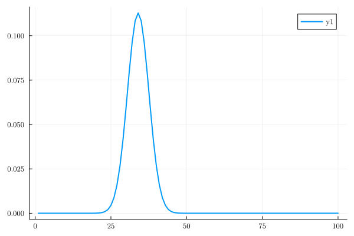

```julia
1ψx = gaussianstate(x_basis, div(size, 3), 0.0, 5)
2ψl = Ket(H0.basis_r, ψx.data)
3
4P0 = Operator(ψl.basis, ψl.data * ψl.data')
5d = lattice_density(P0)
6plot(d.values)
```

```julia
 1g = 2; Δ = 2
 2density_rec = []
 3@evolution show_progress=false {H := h(t, g, Δ), P0 --> H --> P} for t in 0:0.01:20
 4    d = lattice_density(P) .|> real
 5    push!(density_rec,d.values)
 6end
 7p1 = heatmap(hcat(density_rec...)', xlabel="lattice site", ylabel="time", title="Δ=±$(Δ)", colorbar=false)
 8
 9density_rec = []
10@evolution show_progress=false {H := h(t, g, Δ, switch= x-> 1), P0 --> H --> P} for t in 0:0.01:20
11    d = lattice_density(P) .|> real
12    push!(density_rec,d.values)
13end
14p2 = heatmap(hcat(density_rec...)', xlabel="lattice site", ylabel="time", title="Δ=$(Δ)", colorbar=false)
15
16density_rec = []
17@evolution show_progress=false {H := h(t, g, Δ, switch= x-> -1), P0 --> H --> P} for t in 0:0.01:20
18    d = lattice_density(P) .|> real
19    push!(density_rec,d.values)
20end
21p3 = heatmap(hcat(density_rec...)', xlabel="lattice site", ylabel="time", title="Δ=-$(Δ)");
```

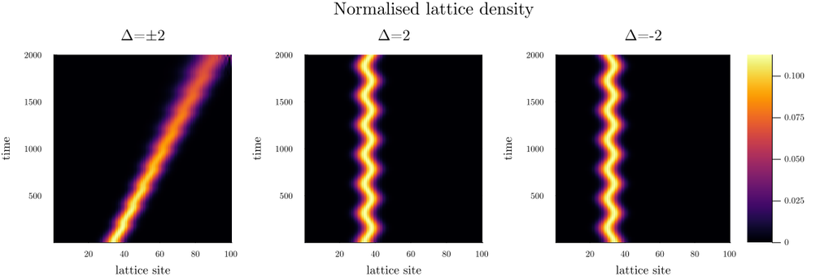

```julia
1l = @layout [a b c{0.42w}]
2plot(p1, p2, p3, layout=l, size=(1200,400), plot_title="Normalised lattice density",
3    margin=5mm, plot_titlevspan=0.1)
4# savefig(plotsdir("lattice_density.png"))
```

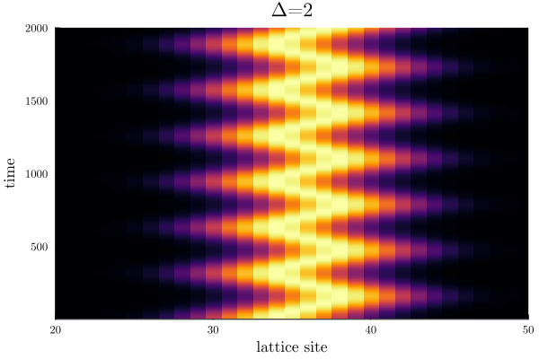

```julia
1plot(p2, xlim=(20, 50))
```

```julia
1function evolution_operator(h, t)
2    H = h(t)
3    ev_op = Operator(basis(H), H.data)
4    LM.evolution_operator!(ev_op, H, t)
5    return ev_op
6end
7time_hamiltonian = t -> h(t, 2, 2)
8ev_op = evolution_operator(time_hamiltonian, 2.1)
```

[output not shown]